# Assignment_4

Ashrith

2025-10-26

```r
library(caret)
#install.packages("factoextra")
library(factoextra)
library(dplyr)
```

```r
library(ggplot2)
library(tidyverse)
#install.packages("cowplot")
library(cowplot)
library(readr)
#install.packages("flexclust")
library(flexclust)
```

```r
#install.packages("cluster")
library(cluster)
```

```r
#install.packages("NbClust")
library(NbClust)
```

```r
Pharmaceuticals <- read.csv("C:/Users/ashri/Downloads/Pharmaceuticals.csv")
###to read the given dataset
View(Pharmaceuticals)
###to view the given dataset.
head(Pharmaceuticals)
```

```
##   Symbol                Name Market_Cap Beta PE_Ratio  ROE  ROA Asset_Turnover
## 1    ABT Abbott Laboratories      68.44 0.32     24.7 26.4 11.8            0.7
## 2    AGN      Allergan, Inc.       7.58 0.41     82.5 12.9  5.5            0.9
## 3    AHM        Amersham plc       6.30 0.46     20.7 14.9  7.8            0.9
## 4    AZN     AstraZeneca PLC      67.63 0.52     21.5 27.4 15.4            0.9
## 5    AVE             Aventis      47.16 0.32     20.1 21.8  7.5            0.6
## 6    BAY            Bayer AG      16.90 1.11     27.9  3.9  1.4            0.6
##   Leverage Rev_Growth Net_Profit_Margin Median_Recommendation Location Exchange
## 1     0.42       7.54              16.1          Moderate Buy       US     NYSE
## 2     0.60       9.16               5.5          Moderate Buy   CANADA     NYSE
## 3     0.27       7.05              11.2            Strong Buy       UK     NYSE
## 4     0.00      15.00              18.0         Moderate Sell       UK     NYSE
## 5     0.34      26.81              12.9          Moderate Buy   FRANCE     NYSE
## 6     0.00      -3.17               2.6                  Hold  GERMANY     NYSE
```

```r
###To retrieve the initial observations from the provided dataset.
str(Pharmaceuticals)
```

```
## 'data.frame':    21 obs. of  14 variables:
##  $ Symbol               : chr  "ABT" "AGN" "AHM" "AZN" ...
##  $ Name                 : chr  "Abbott Laboratories" "Allergan, Inc." "Amersham plc" "AstraZeneca PLC" ...
##  $ Market_Cap           : num  68.44 7.58 6.3 67.63 47.16 ...
##  $ Beta                 : num  0.32 0.41 0.46 0.52 0.32 1.11 0.5 0.85 1.08 0.18 ...
##  $ PE_Ratio             : num  24.7 82.5 20.7 21.5 20.1 27.9 13.9 26 3.6 27.9 ...
##  $ ROE                  : num  26.4 12.9 14.9 27.4 21.8 3.9 34.8 24.1 15.1 31 ...
##  $ ROA                  : num  11.8 5.5 7.8 15.4 7.5 1.4 15.1 4.3 5.1 13.5 ...
##  $ Asset_Turnover       : num  0.7 0.9 0.9 0.9 0.6 0.6 0.9 0.6 0.3 0.6 ...
##  $ Leverage             : num  0.42 0.6 0.27 0 0.34 0 0.57 3.51 1.07 0.53 ...
##  $ Rev_Growth           : num  7.54 9.16 7.05 15 26.81 ...
##  $ Net_Profit_Margin    : num  16.1 5.5 11.2 18 12.9 2.6 20.6 7.5 13.3 23.4 ...
##  $ Median_Recommendation: chr  "Moderate Buy" "Moderate Buy" "Strong Buy" "Moderate Sell" ...
##  $ Location             : chr  "US" "CANADA" "UK" "UK" ...
##  $ Exchange             : chr  "NYSE" "NYSE" "NYSE" "NYSE" ...
```

```r
###To examine the format of the provided dataset.
summary(Pharmaceuticals)
```

```
##     Symbol              Name             Market_Cap          Beta
##  Length:21          Length:21          Min.   :  0.41   Min.   :0.1800
##  Class :character   Class :character   1st Qu.:  6.30   1st Qu.:0.3500
##  Mode  :character   Mode  :character   Median : 48.19   Median :0.4600
##                                        Mean   : 57.65   Mean   :0.5257
##                                        3rd Qu.: 73.84   3rd Qu.:0.6500
##                                        Max.   :199.47   Max.   :1.1100
##     PE_Ratio          ROE            ROA        Asset_Turnover    Leverage
##  Min.   : 3.60   Min.   : 3.9   Min.   : 1.40   Min.   :0.3    Min.   :0.0000
##  1st Qu.:18.90   1st Qu.:14.9   1st Qu.: 5.70   1st Qu.:0.6    1st Qu.:0.1600
##  Median :21.50   Median :22.6   Median :11.20   Median :0.6    Median :0.3400
##  Mean   :25.46   Mean   :25.8   Mean   :10.51   Mean   :0.7    Mean   :0.5857
##  3rd Qu.:27.90   3rd Qu.:31.0   3rd Qu.:15.00   3rd Qu.:0.9    3rd Qu.:0.6000
##  Max.   :82.50   Max.   :62.9   Max.   :20.30   Max.   :1.1    Max.   :3.5100
##    Rev_Growth    Net_Profit_Margin Median_Recommendation   Location
##  Min.   :-3.17   Min.   : 2.6      Length:21             Length:21
##  1st Qu.: 6.38   1st Qu.:11.2      Class :character      Class :character
##  Median : 9.37   Median :16.1      Mode  :character      Mode  :character
##  Mean   :13.37   Mean   :15.7
##  3rd Qu.:21.87   3rd Qu.:21.1
##  Max.   :34.21   Max.   :25.5
##    Exchange
##  Length:21
##  Class :character
##  Mode  :character
##
##
##
```

```r
###To examine an overview of the provided dataset.
dim(Pharmaceuticals)
```

```
## [1] 21 14
```

```r
###To determine the number of rows and columns present in the provided dataset.
colMeans(is.na(Pharmaceuticals))
```

```
##                Symbol                  Name            Market_Cap
##                     0                     0                     0
##                  Beta              PE_Ratio                   ROE
##                     0                     0                     0
##                   ROA        Asset_Turnover              Leverage
##                     0                     0                     0
##            Rev_Growth     Net_Profit_Margin Median_Recommendation
##                     0                     0                     0
##              Location              Exchange
##                     0                     0
```

```r
row.names(Pharmaceuticals) <- Pharmaceuticals[,2]
Pharmaceuticals <- Pharmaceuticals[,-2]
```

FIRST QUESTION:

a.Use only the numerical variables (1 to 9) to cluster the 21 firms. Justify the various choices made in conducting the cluster analysis, such as weights for different variables, the specific clustering algorithm(s) used, the number of clusters formed, and so on.

```r
Pharmaceuticals1 <- Pharmaceuticals[,-c(1,11:13)]
###with exception of "Symbol" and the last three non-numerical variables.
```

NORMALIZING AND CLUSTERING THE DATA

Here, I have calculated the difference between each observation, and it’s important to modify the data beforehand because the default Euclidean distance measure is sensitive to scale.

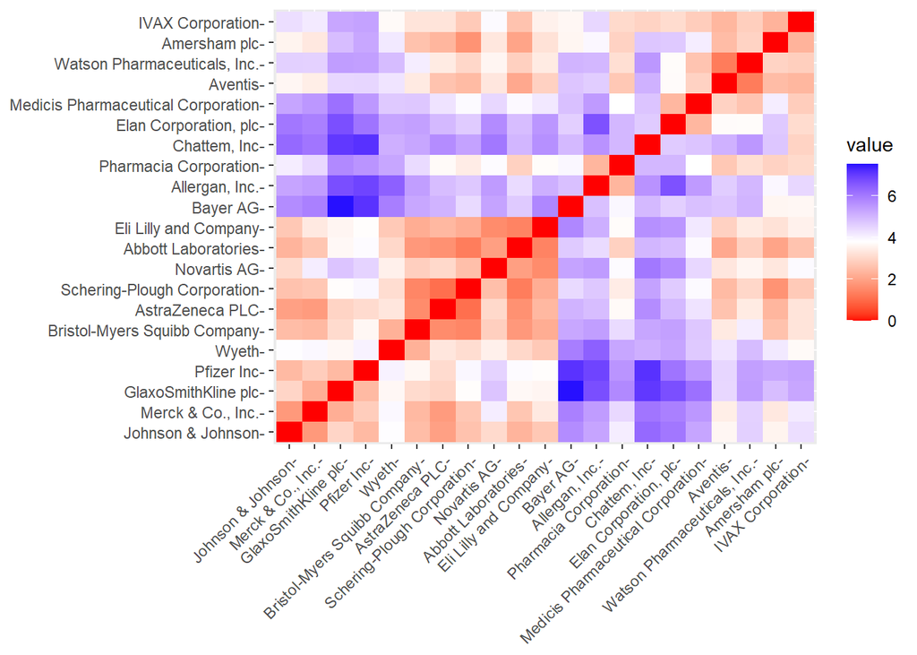

```r
norm.Pharmaceuticals1 <- scale(Pharmaceuticals1)
###the data is normalized.
distance <- get_dist(norm.Pharmaceuticals1)
fviz_dist(distance)
```

```r
###to measure and plot distance for the given dataset.
```

```
The graph illustrates the change in color intensity as distance increases. As expected, the diagonal line     shows a value of zero, indicating the distance between two observations.
```

#To find the Optimal K value

```
The Elbow chart and the Silhouette Method are the best techniques for deciding the number of clusters in a k-means model when there are no external factors. The Elbow chart shows that increasing the number of clusters leads to less variation within each cluster, while the Silhouette Method measures how connected an object's cluster is to others.
```

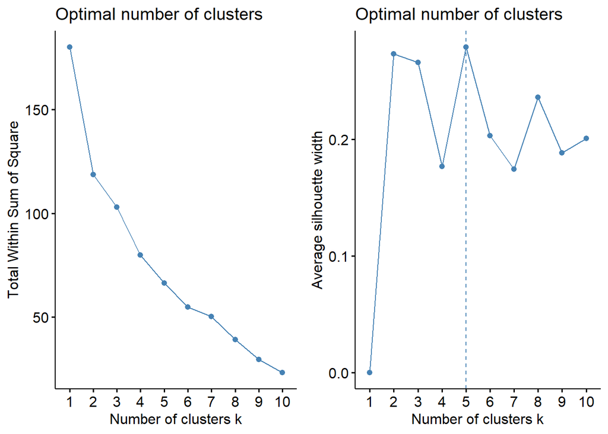

```r
WSS <- fviz_nbclust(norm.Pharmaceuticals1, kmeans, method = "wss")
Silhouette <- fviz_nbclust(norm.Pharmaceuticals1, kmeans, method = "silhouette")
plot_grid(WSS, Silhouette)
```

```r
###we used elbow chart and silhouette methods.
set.seed(123)
Kmeans.Pharmaceuticals.Optimalno <- kmeans(norm.Pharmaceuticals1, centers = 5, nstart = 50)
Kmeans.Pharmaceuticals.Optimalno$centers
```

```
##    Market_Cap       Beta    PE_Ratio        ROE        ROA Asset_Turnover
## 1 -0.03142211 -0.4360989 -0.31724852  0.1950459  0.4083915      0.1729746
## 2 -0.87051511  1.3409869 -0.05284434 -0.6184015 -1.1928478     -0.4612656
## 3 -0.43925134 -0.4701800  2.70002464 -0.8349525 -0.9234951      0.2306328
## 4  1.69558112 -0.1780563 -0.19845823  1.2349879  1.3503431      1.1531640
## 5 -0.76022489  0.2796041 -0.47742380 -0.7438022 -0.8107428     -1.2684804
##      Leverage Rev_Growth Net_Profit_Margin
## 1 -0.27449312 -0.7041516       0.556954446
## 2  1.36644699 -0.6912914      -1.320000179
## 3 -0.14170336 -0.1168459      -1.416514761
## 4 -0.46807818  0.4671788       0.591242521
## 5  0.06308085  1.5180158      -0.006893899
```

```r
Kmeans.Pharmaceuticals.Optimalno$size
```

```
## [1] 8 3 2 4 4
```

```r
Kmeans.Pharmaceuticals.Optimalno$withinss
```

```
## [1] 21.879320 15.595925  2.803505  9.284424 12.791257
```

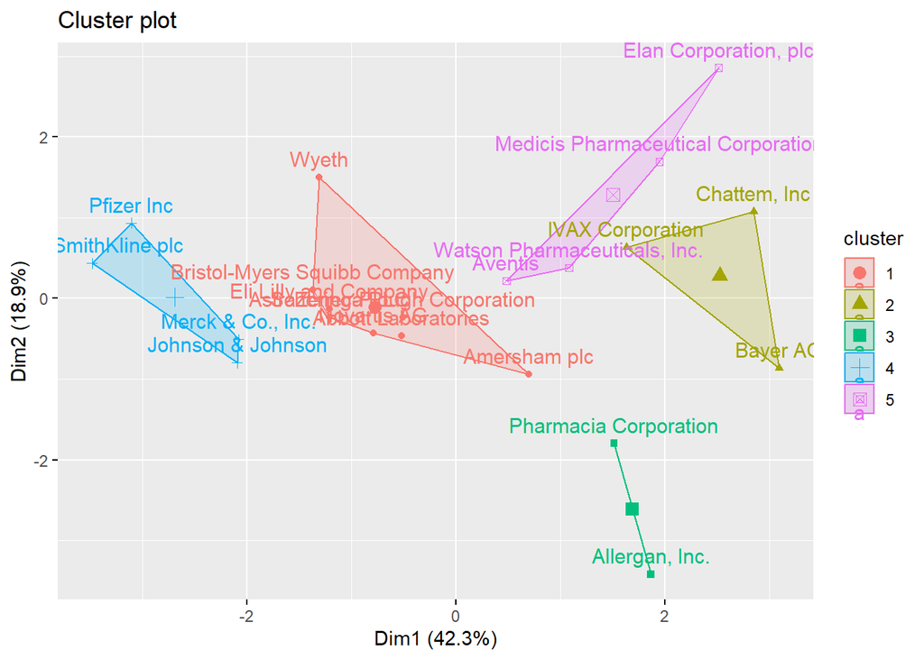

```r
fviz_cluster(Kmeans.Pharmaceuticals.Optimalno, data = norm.Pharmaceuticals1)
```

> Based on the data, we can classify five clusters based on their proximity to the centroids. Cluster 4 exhibits a high Market Capital, while Cluster 2 shows a high Beta, and Cluster 5 has a low Asset Turnover. We can also determine the size of each cluster, with Cluster 1 having the highest number of enterprises, while Cluster 3 contains only two. The sum of squared distances within each cluster provides insights into data dispersion: Cluster 1 (21.9) shows less uniformity compared to Cluster 3 (2.8). Through visualizing the output of the algorithm, we can observe the division of the data into these five distinct groups.

SECOND QUESTION:

b.Interpret the clusters with respect to the numerical variables used in forming the clusters

```r
###Employing k-means with k=3 to create clusters.
set.seed(123)
Kmeans.Pharmaceuticals <- kmeans(norm.Pharmaceuticals1, centers =3, nstart = 50)
Kmeans.Pharmaceuticals$centers
```

```
##   Market_Cap       Beta   PE_Ratio        ROE        ROA Asset_Turnover
## 1 -0.6125361  0.2698666  1.3143935 -0.9609057 -1.0174553      0.2306328
## 2  0.6733825 -0.3586419 -0.2763512  0.6565978  0.8344159      0.4612656
## 3 -0.8261772  0.4775991 -0.3696184 -0.5631589 -0.8514589     -0.9994088
##     Leverage Rev_Growth Net_Profit_Margin
## 1 -0.3592866 -0.5757385        -1.3784169
## 2 -0.3331068 -0.2902163         0.6823310
## 3  0.8502201  0.9158889        -0.3319956
```

```r
Kmeans.Pharmaceuticals$size
```

```
## [1]  4 11  6
```

```r
Kmeans.Pharmaceuticals$withinss
```

```
## [1] 20.54199 43.30886 32.14336
```

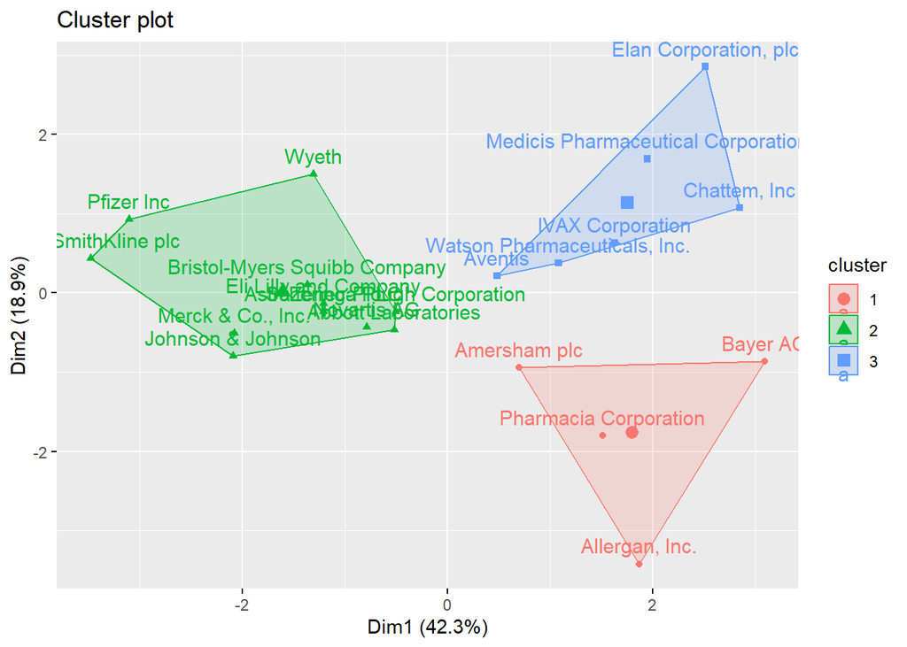

```r
fviz_cluster(Kmeans.Pharmaceuticals, data = norm.Pharmaceuticals1)
```

> This simplifies the process of identifying and handling the clusters within the analysis. Currently, there are 4 data points allocated to cluster 1, 11 data points assigned to cluster 2, and 6 data points designated to cluster 3.

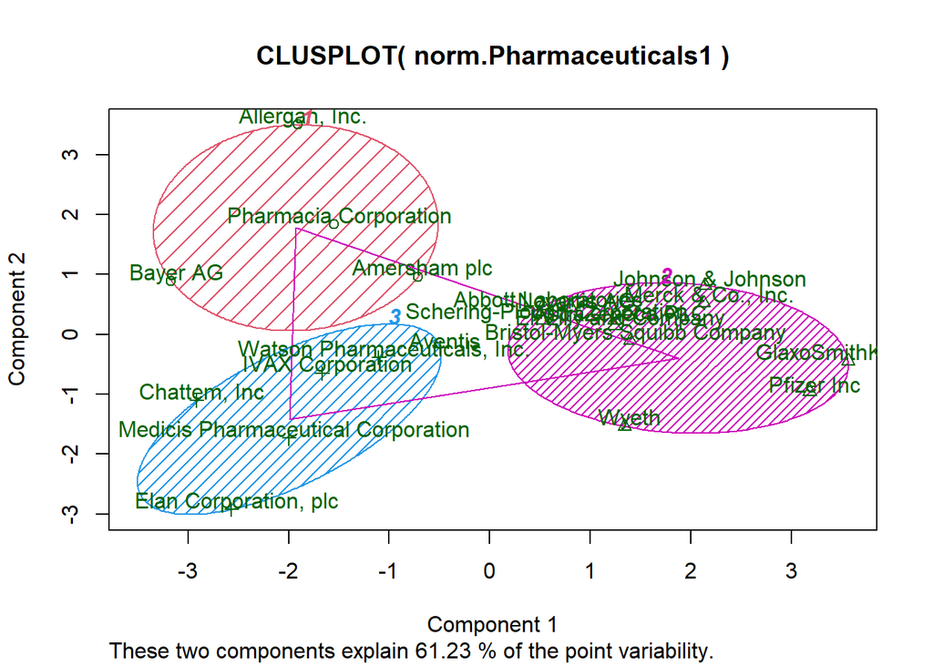

```r
clusplot(norm.Pharmaceuticals1, Kmeans.Pharmaceuticals$cluster, color = TRUE, shade = TRUE, labels = 2,,lines= TRUE)
```

THIRD QUESTION

3. Is there a pattern in the clusters with respect to the numerical variables (10 to 12)? (those not used in forming the clusters)

   By examining the three final categorical variables, namely Median_Recommendation, Location, and Stock Exchange, I aim to identify any patterns in the dataset. I prefer to utilize bar charts to visually represent how firms are distributed across clusters.

```r
###dataset is partitioned for last 3 variables.
Pharmaceuticals3 <- Pharmaceuticals %>% select(c(11,12,13)) %>%
  mutate(Cluster = Kmeans.Pharmaceuticals$cluster)
```

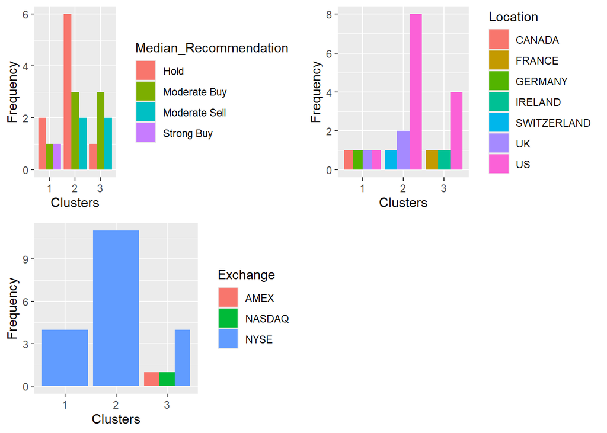

```r
Median_Rec <- ggplot(Pharmaceuticals3, mapping = aes(factor(Cluster), fill=Median_Recommendation)) +
geom_bar(position = 'dodge') +
labs(x='Clusters', y='Frequency')
Location <- ggplot(Pharmaceuticals3, mapping = aes(factor(Cluster), fill=Location)) +
geom_bar(position = 'dodge') +
labs(x='Clusters', y='Frequency')
Exchange <- ggplot(Pharmaceuticals3, mapping = aes(factor(Cluster), fill=Exchange)) +
geom_bar(position = 'dodge') +
labs(x='Clusters', y='Frequency')
plot_grid(Median_Rec,Location,Exchange)
```

FOURTH QUESTION:

d.Provide an appropriate name for each cluster using any or all of the variables in the dataset.

Here, we can gather all the provided data from the dataset and identify the three distinct groups among the 21 pharmaceutical companies.

Cluster 1 is termed as ‘overvalued international firms’ due to the subsequent factors: international presence, trading on NYSE, low Net Profit Margin, and high Price/Earnings ratio. These companies operate across multiple continents while raising funds on the world’s largest stock exchange (NYSE). They possess high market valuations that surpass their current earnings levels. To prevent a potential collapse in their stock prices, they must invest and enhance their earnings to meet investor expectations.